# Amirali Rahimi 810100146

# CA4 - Machine Learning

```python
import pandas as pd
import numpy as np
import seaborn as sb
from sklearn.preprocessing import LabelEncoder, StandardScaler, MinMaxScaler
from sklearn.model_selection import train_test_split, GridSearchCV
from sklearn.tree import DecisionTreeClassifier
from sklearn.neighbors import KNeighborsClassifier
from sklearn.linear_model import LogisticRegression
from sklearn.ensemble import RandomForestClassifier
from sklearn.tree import plot_tree
from sklearn.metrics import confusion_matrix
import matplotlib.pyplot as plt
import math
from mlxtend.evaluate import bias_variance_decomp
from xgboost import XGBClassifier
```

## Importing Data and Checking Corrolation Between Features

```python
marketingDataDF = pd.read_csv("marketing_campaign.csv")
marketingDataDF.info()
marketingDataDF.describe()
```

```
<class 'pandas.core.frame.DataFrame'>
RangeIndex: 2240 entries, 0 to 2239
Data columns (total 20 columns):
 #   Column             Non-Null Count  Dtype
---  ------             --------------  -----
 0   Unnamed: 0         2240 non-null   int64
 1   ID                 2240 non-null   int64
 2   Year_Birth         2240 non-null   int64
 3   Education          2240 non-null   object
 4   Marital_Status     2240 non-null   object
 5   Income             2017 non-null   float64
 6   Kidhome            2240 non-null   int64
 7   Teenhome           2240 non-null   int64
 8   Dt_Customer        2240 non-null   object
 9   Recency            2240 non-null   int64
 10  MntCoffee          2035 non-null   float64
 11  MntFruits          2240 non-null   int64
 12  MntMeatProducts    2240 non-null   int64
 13  MntFishProducts    2240 non-null   int64
 14  MntSweetProducts   2240 non-null   int64
 15  MntGoldProds       2227 non-null   float64
 16  NumWebVisitsMonth  2040 non-null   float64
 17  Complain           2240 non-null   int64
 18  NumPurchases       2240 non-null   int64
 19  UsedCampaignOffer  2240 non-null   int64
dtypes: float64(4), int64(13), object(3)
memory usage: 350.1+ KB
```

|  | Unnamed: 0 | ID | Year_Birth | Income | Kidhome | Teenhome | Recency | MntCoffee | MntFruits | MntMeatProducts | MntFishProducts | MntSweetProducts | MntGoldProds | NumWebVisitsMonth | Complain | NumPurchases | UsedCampaignOffer |
| --- | --- | --- | --- | --- | --- | --- | --- | --- | --- | --- | --- | --- | --- | --- | --- | --- | --- |
| count | 2240.000000 | 2240.000000 | 2240.000000 | 2017.000000 | 2240.000000 | 2240.000000 | 2240.000000 | 2035.000000 | 2240.000000 | 2240.000000 | 2240.000000 | 2240.000000 | 2227.000000 | 2040.000000 | 2240.000000 | 2240.000000 | 2240.000000 |
| mean | 1119.500000 | 5592.159821 | 1968.805804 | 52297.080317 | 0.437946 | 0.506250 | 49.109375 | 304.239312 | 26.302232 | 166.950000 | 37.525446 | 27.062946 | 43.847777 | 5.326961 | 0.009375 | 14.862054 | 0.271875 |
| std | 646.776623 | 3246.662198 | 11.984069 | 25543.108215 | 0.563666 | 0.544538 | 28.962453 | 337.515534 | 39.773434 | 225.715373 | 54.628979 | 41.280498 | 51.897098 | 2.439349 | 0.096391 | 7.677173 | 0.445025 |
| min | 0.000000 | 0.000000 | 1893.000000 | 2447.000000 | -5.000000 | 0.000000 | 0.000000 | 0.000000 | 0.000000 | 0.000000 | 0.000000 | 0.000000 | 0.000000 | 0.000000 | 0.000000 | 0.000000 | 0.000000 |
| 25% | 559.750000 | 2828.250000 | 1959.000000 | 35340.000000 | 0.000000 | 0.000000 | 24.000000 | 23.000000 | 1.000000 | 16.000000 | 3.000000 | 1.000000 | 9.000000 | 3.000000 | 0.000000 | 8.000000 | 0.000000 |
| 50% | 1119.500000 | 5458.500000 | 1970.000000 | 51369.000000 | 0.000000 | 0.000000 | 49.000000 | 177.000000 | 8.000000 | 67.000000 | 12.000000 | 8.000000 | 24.000000 | 6.000000 | 0.000000 | 15.000000 | 0.000000 |
| 75% | 1679.250000 | 8427.750000 | 1977.000000 | 68316.000000 | 1.000000 | 1.000000 | 74.000000 | 505.000000 | 33.000000 | 232.000000 | 50.000000 | 33.000000 | 56.000000 | 7.000000 | 0.000000 | 21.000000 | 1.000000 |
| max | 2239.000000 | 11191.000000 | 1996.000000 | 666666.000000 | 2.000000 | 2.000000 | 99.000000 | 1493.000000 | 199.000000 | 1725.000000 | 259.000000 | 263.000000 | 362.000000 | 20.000000 | 1.000000 | 44.000000 | 1.000000 |

#### Question 2: Find NaN Number and Ratio

```python
marketingDataDF = marketingDataDF.drop(marketingDataDF.columns[0], axis=1)
nullValueNums = {}
for data in marketingDataDF.columns:
    nullValueNums[data] = marketingDataDF[data].isna().sum()

totalRows = len(marketingDataDF)
nullValueRatio = {col:round(num/totalRows,2) for col,num in nullValueNums.items()}

nullSummaryDF = pd.DataFrame({
    'Feature Name': list(nullValueNums.keys()),
    'Number of NaNs': list(nullValueNums.values()),
    'Ratio of NaNs': list(nullValueRatio.values())
})

display(nullSummaryDF)
```

|  | Feature Name | Number of NaNs | Ratio of NaNs |
| --- | --- | --- | --- |
| 0 | ID | 0 | 0.00 |
| 1 | Year_Birth | 0 | 0.00 |
| 2 | Education | 0 | 0.00 |
| 3 | Marital_Status | 0 | 0.00 |
| 4 | Income | 223 | 0.10 |
| 5 | Kidhome | 0 | 0.00 |
| 6 | Teenhome | 0 | 0.00 |
| 7 | Dt_Customer | 0 | 0.00 |
| 8 | Recency | 0 | 0.00 |
| 9 | MntCoffee | 205 | 0.09 |
| 10 | MntFruits | 0 | 0.00 |
| 11 | MntMeatProducts | 0 | 0.00 |
| 12 | MntFishProducts | 0 | 0.00 |
| 13 | MntSweetProducts | 0 | 0.00 |
| 14 | MntGoldProds | 13 | 0.01 |
| 15 | NumWebVisitsMonth | 200 | 0.09 |
| 16 | Complain | 0 | 0.00 |
| 17 | NumPurchases | 0 | 0.00 |
| 18 | UsedCampaignOffer | 0 | 0.00 |

#### Question 3: Look for connections between features and identify the ones that have the strongest relationship with the target.

```python
marketingDataDFEncoded = marketingDataDF.copy()
label_encoder = LabelEncoder()
for col in marketingDataDFEncoded.select_dtypes(include=[object]).columns:
    marketingDataDFEncoded[col] = label_encoder.fit_transform(marketingDataDFEncoded[col])
corrMatrix = marketingDataDFEncoded.corr()
display(corrMatrix.style.background_gradient(cmap='Blues').format("{:.2f}"))
```

|  | ID | Year_Birth | Education | Marital_Status | Income | Kidhome | Teenhome | Dt_Customer | Recency | MntCoffee | MntFruits | MntMeatProducts | MntFishProducts | MntSweetProducts | MntGoldProds | NumWebVisitsMonth | Complain | NumPurchases | UsedCampaignOffer |
| --- | --- | --- | --- | --- | --- | --- | --- | --- | --- | --- | --- | --- | --- | --- | --- | --- | --- | --- | --- |
| ID | 1.00 | 0.00 | -0.00 | 0.02 | 0.02 | 0.00 | -0.00 | -0.03 | -0.05 | -0.02 | 0.00 | -0.00 | -0.02 | -0.01 | -0.01 | -0.02 | 0.03 | -0.02 | -0.03 |
| Year_Birth | 0.00 | 1.00 | -0.17 | -0.06 | -0.16 | 0.22 | -0.35 | -0.01 | -0.02 | -0.17 | -0.02 | -0.03 | -0.04 | -0.02 | -0.05 | 0.13 | -0.03 | -0.17 | -0.03 |
| Education | -0.00 | -0.17 | 1.00 | 0.01 | 0.13 | -0.05 | 0.12 | 0.02 | -0.01 | 0.20 | -0.08 | 0.03 | -0.11 | -0.11 | -0.10 | -0.04 | -0.05 | 0.09 | 0.07 |
| Marital_Status | 0.02 | -0.06 | 0.01 | 1.00 | 0.02 | -0.02 | -0.00 | -0.02 | 0.01 | 0.01 | 0.00 | 0.03 | 0.04 | 0.02 | 0.00 | -0.04 | -0.01 | 0.00 | 0.00 |
| Income | 0.02 | -0.16 | 0.13 | 0.02 | 1.00 | -0.40 | 0.02 | -0.03 | -0.00 | 0.56 | 0.42 | 0.57 | 0.43 | 0.43 | 0.32 | -0.54 | -0.03 | 0.56 | 0.23 |
| Kidhome | 0.00 | 0.22 | -0.05 | -0.02 | -0.40 | 1.00 | -0.03 | -0.01 | 0.02 | -0.48 | -0.35 | -0.42 | -0.37 | -0.35 | -0.33 | 0.42 | 0.04 | -0.45 | -0.17 |
| Teenhome | -0.00 | -0.35 | 0.12 | -0.00 | 0.02 | -0.03 | 1.00 | 0.01 | 0.02 | 0.02 | -0.18 | -0.26 | -0.20 | -0.16 | -0.02 | 0.13 | 0.00 | 0.13 | -0.13 |
| Dt_Customer | -0.03 | -0.01 | 0.02 | -0.02 | -0.03 | -0.01 | 0.01 | 1.00 | 0.01 | -0.00 | -0.02 | -0.01 | -0.02 | 0.00 | 0.00 | 0.02 | -0.01 | -0.01 | 0.00 |
| Recency | -0.05 | -0.02 | -0.01 | 0.01 | -0.00 | 0.02 | 0.02 | 0.01 | 1.00 | 0.02 | -0.00 | 0.02 | 0.00 | 0.02 | 0.02 | -0.02 | 0.01 | 0.01 | -0.10 |
| MntCoffee | -0.02 | -0.17 | 0.20 | 0.01 | 0.56 | -0.48 | 0.02 | -0.00 | 0.02 | 1.00 | 0.38 | 0.56 | 0.40 | 0.38 | 0.39 | -0.32 | -0.04 | 0.72 | 0.43 |
| MntFruits | 0.00 | -0.02 | -0.08 | 0.00 | 0.42 | -0.35 | -0.18 | -0.02 | -0.00 | 0.38 | 1.00 | 0.54 | 0.59 | 0.57 | 0.39 | -0.41 | -0.01 | 0.46 | 0.15 |
| MntMeatProducts | -0.00 | -0.03 | 0.03 | 0.03 | 0.57 | -0.42 | -0.26 | -0.01 | 0.02 | 0.56 | 0.54 | 1.00 | 0.57 | 0.52 | 0.35 | -0.54 | -0.02 | 0.55 | 0.30 |
| MntFishProducts | -0.02 | -0.04 | -0.11 | 0.04 | 0.43 | -0.37 | -0.20 | -0.02 | 0.00 | 0.40 | 0.59 | 0.57 | 1.00 | 0.58 | 0.42 | -0.45 | -0.02 | 0.47 | 0.16 |
| MntSweetProducts | -0.01 | -0.02 | -0.11 | 0.02 | 0.43 | -0.35 | -0.16 | 0.00 | 0.02 | 0.38 | 0.57 | 0.52 | 0.58 | 1.00 | 0.37 | -0.42 | -0.02 | 0.47 | 0.16 |
| MntGoldProds | -0.01 | -0.05 | -0.10 | 0.00 | 0.32 | -0.33 | -0.02 | 0.00 | 0.02 | 0.39 | 0.39 | 0.35 | 0.42 | 0.37 | 1.00 | -0.24 | -0.03 | 0.49 | 0.19 |
| NumWebVisitsMonth | -0.02 | 0.13 | -0.04 | -0.04 | -0.54 | 0.42 | 0.13 | 0.02 | -0.02 | -0.32 | -0.41 | -0.54 | -0.45 | -0.42 | -0.24 | 1.00 | 0.02 | -0.31 | -0.08 |
| Complain | 0.03 | -0.03 | -0.05 | -0.01 | -0.03 | 0.04 | 0.00 | -0.01 | 0.01 | -0.04 | -0.01 | -0.02 | -0.02 | -0.02 | -0.03 | 0.02 | 1.00 | -0.02 | -0.03 |
| NumPurchases | -0.02 | -0.17 | 0.09 | 0.00 | 0.56 | -0.45 | 0.13 | -0.01 | 0.01 | 0.72 | 0.46 | 0.55 | 0.47 | 0.47 | 0.49 | -0.31 | -0.02 | 1.00 | 0.25 |
| UsedCampaignOffer | -0.03 | -0.03 | 0.07 | 0.00 | 0.23 | -0.17 | -0.13 | 0.00 | -0.10 | 0.43 | 0.15 | 0.30 | 0.16 | 0.16 | 0.19 | -0.08 | -0.03 | 0.25 | 1.00 |

```python
target = 'NumPurchases'
sorted_features = corrMatrix[target].sort_values(ascending=False)
top_four_features = sorted_features[1:5]
for feature, corr in top_four_features.items():
    print(feature)
```

```
MntCoffee
Income
MntMeatProducts
MntGoldProds
```

#### Question 4: Draw a chart showing the number of observations for each unique value of the features obtained in the previous step.

```python
def draw_histograms(df, title):
    fig, axs = plt.subplots(5, 4)
    fig.suptitle(title, fontsize=25)
    fig.set_figheight(20)
    fig.set_figwidth(25)
    i=0
    for col in df.columns:
        df[col].hist(ax=axs[int(i/4)][(i%4)])
        axs[int(i/4)][(i%4)].set_title(col)
        i += 1
    plt.show()
```

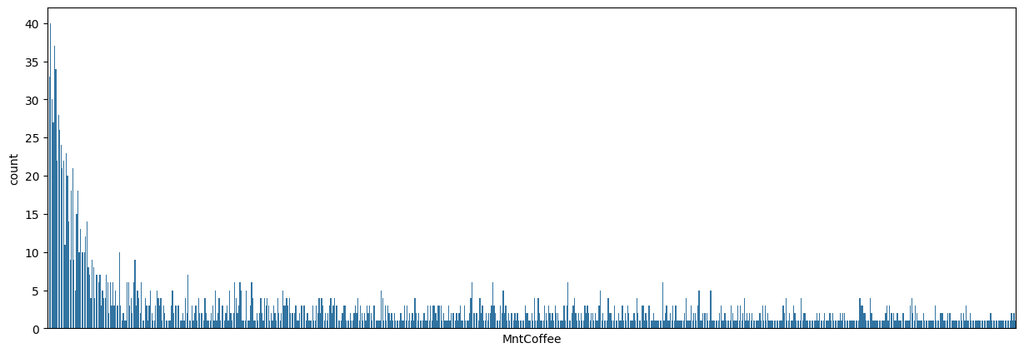

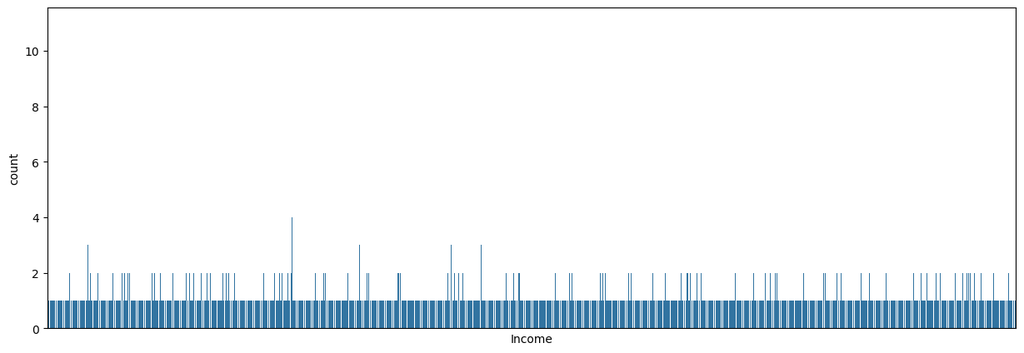

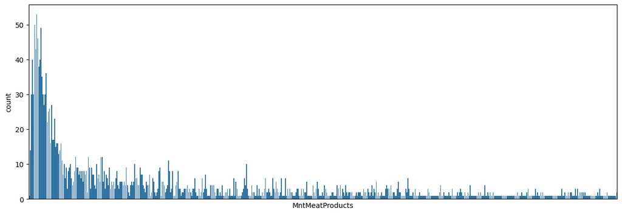

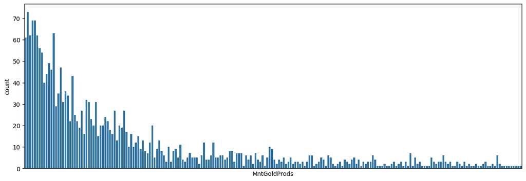

```python
for feature, corr in top_four_features.items():
    plt.figure(figsize=(15, 5))
    plt.xticks(rotation=90)
    sb.countplot(data=marketingDataDFEncoded, x=feature)
    plt.xticks(ticks=[], labels=[])
```

Since our `data is continuous`, these plots aren’t very helpful for interpretation. Therefore, `we’ll use histograms instead`.

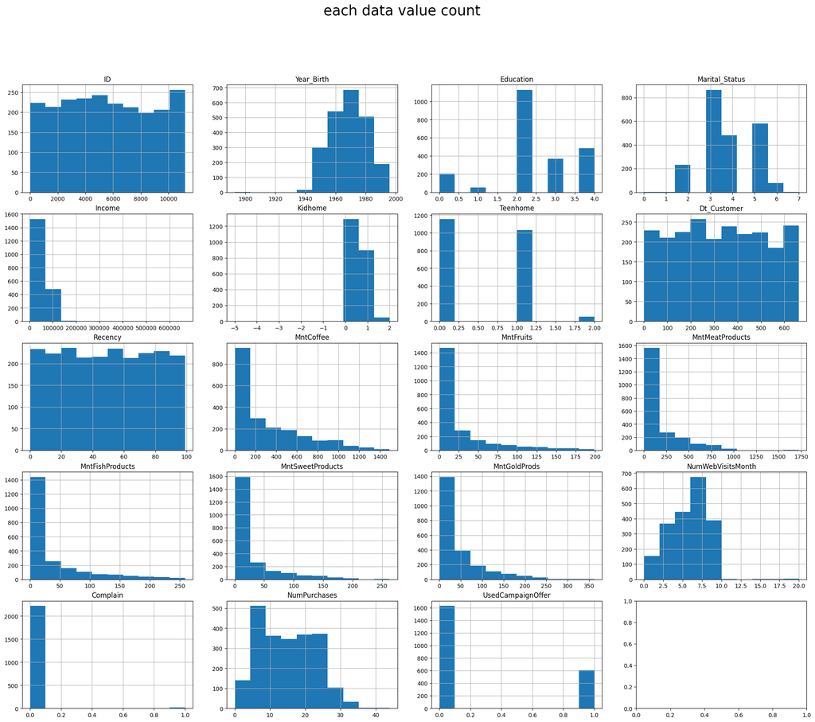

```python
draw_histograms(marketingDataDFEncoded, "each data value count")
```

#### Question 5: Draw scatter plot for the visualizing corrlation between features

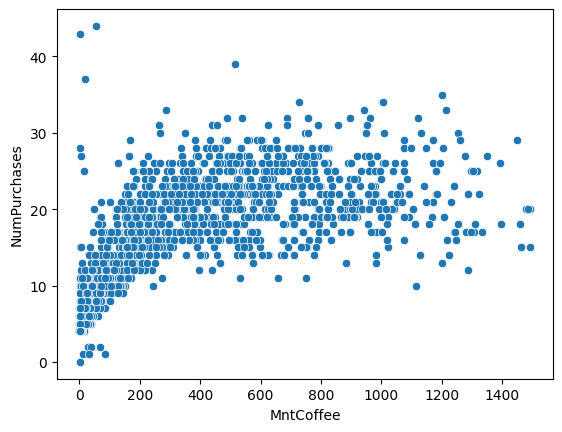

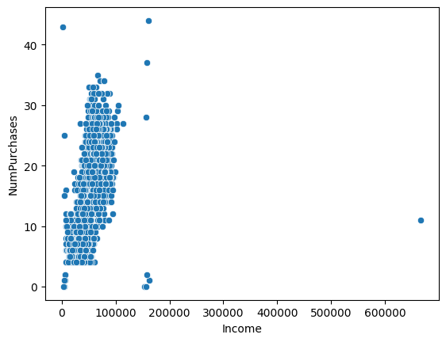

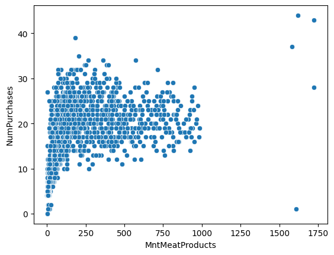

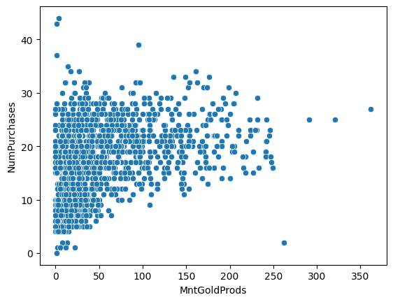

```python
for feature, corr in top_four_features.items():
    plt.figure()
    sb.scatterplot(data=marketingDataDFEncoded, x=feature, y=target)
```

## Preprocess on Samples:

### Question 7: Strategies for Handling Missing Data

#### Filling in Missing Data:

This involves substituting missing data with a calculated value.

- **Average Value Replacement:**  
  It's straightforward - if data is missing, we fill it in with the average value from the rest of the column. This method may not be suitable for all types of data.
- **Median Value Replacement:**  
  When outliers affect the average, the median provides a more accurate fill as it's the middle value in the data.
- **Most Common Value Replacement:**  
  For categorical data where average and median don't make sense, the most frequently occurring value (mode) is used.
- **Random Value Replacement:**  
  Filling in missing data with a random value that falls within the existing data range.
- **Next or Previous Value Replacement:**  
  Also known as forward-fill or backward-fill, this method uses the subsequent or prior value to replace a missing one.

More sophisticated methods like k-nearest neighbors or MICE apply complex algorithms to predict suitable replacements based on the data's overall patterns.

#### Dropping Data:

- **Drop Columns:**  
  If a column is mostly empty, sometimes it's simpler to just remove it, especially if it isn't critical to your analysis.
- **Drop Rows:**  
  Similar to dropping columns, but here we remove rows with missing data. Only consider this option when a significant portion of data in a row is missing.

Alternatively, when the dataset has few missing elements, ignoring them can also be a viable approach to proceed with the analysis.

### Question 8: Based on the results of the previous phase, which data has the highest amount of missing data? Resolve the missing data issue for all features using the aforementioned methods.

```python
for feature in marketingDataDFEncoded.columns:
    marketingDataDFEncoded[feature] = marketingDataDFEncoded[feature].fillna(marketingDataDFEncoded[feature].mean())
```

#### Question 9: In numerical features, what is the purpose of performing normalizing or standardizing? Is there a need to do this in this project?

Normalization standardizes the range of numerical values in a dataset. It's essential for algorithms that are sensitive to the scale of data and works well when the data doesn't contain outliers and is bound within a range. The formula using `MinMaxScaler` is given by:

$$X_{norm} = \frac{X - X_{min}}{X_{max} - X_{min}}$$

This scales the values between [0, 1] or [-1, 1], ideal for unknown or non-Gaussian distributions.

Standardization, on the other hand, shifts the distribution of each attribute to have a mean of 0 and a standard deviation of 1, using the formula:

$$X_{std} = \frac{X - \mu}{\sigma}$$

This technique assumes a Gaussian distribution and is effective for models that rely on this, such as linear regression and logistic regression.

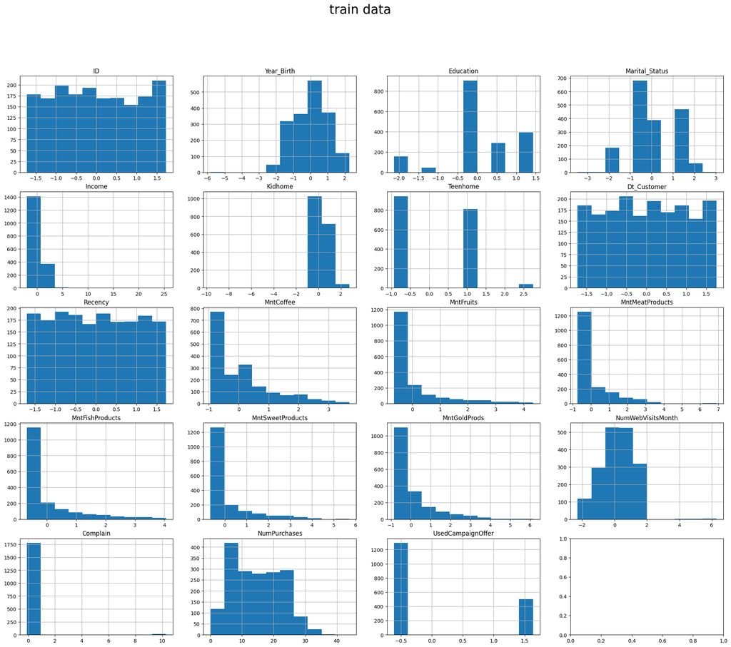

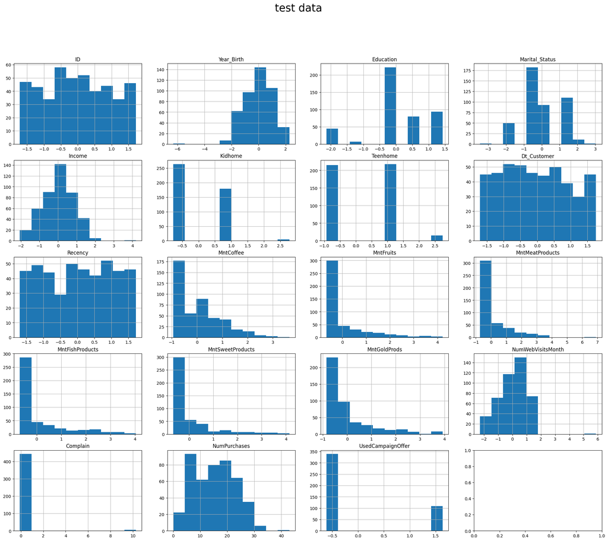

```python
normalizeScaler = MinMaxScaler()
targetCol = marketingDataDFEncoded[target]
normalizedDF = pd.DataFrame(normalizeScaler.fit_transform(marketingDataDFEncoded), columns=marketingDataDFEncoded.columns)
standardScaler = StandardScaler()
standardizedDF = pd.DataFrame(standardScaler.fit_transform(normalizedDF), columns=normalizedDF.columns)
standardizedDF[target] = targetCol
trainData, testData = train_test_split(standardizedDF, test_size=0.2)
draw_histograms(trainData, "train data")
draw_histograms(testData, "test data")
```

### Question 10: To use categorical features, which are typically stored as strings or objects in a dataset, in model training, what preprocessing are useful? Do all categorical data require these methods?

When dealing with categorical features in a dataset, typically stored as strings or objects, various preprocessing methods can be applied to prepare these for model training:

- **One-Hot Encoding**: Generates binary columns for each category, suitable for nominal variables without too many levels.
- **Label Encoding**: Assigns a unique integer to each category, but may imply an unintended order.
- **Ordinal Encoding**: Converts categories to integers according to their ordinal relation, ideal for ordered categories.
- **Binary Encoding**: Mixes binary representation with hashing to reduce dimensionality and maintain category information.
- **Frequency Encoding**: Substitutes categories with their occurrence rates in the dataset, which can correlate with the target variable.
- **Target Encoding**: Replaces categories with the mean target variable, potentially increasing model performance but risking overfitting.
- **Embedding Layers**: Typically used in neural networks, learning an embedding for categories during model training.
- **Hashing Encoding**: Applies a hash function to encode categories, saving space but risking information loss through collisions.

It's important to note that not all categorical data require these encoding methods. The choice of technique depends on factors like unique category count, whether the feature is ordinal or nominal, the machine learning algorithm used, and how closely the features relate to the target variable.

We used label encoding for this project.

### Question 11: Is there a possibility to delete some columns? Why?

Yes, definitely. We can remove columns that don't have a strong correlation with the target column since they won't significantly affect our model's training.

### Question 12: For training and ultimately evaluating a machine learning model, it is necessary to split the data into two sets: test and train. What is the ratio of this split? What methods are there for dividing and creating these two groups?

Different methods can be applied to divide the dataset into training and test sets for machine learning models, including:

- **Cross-Validation**: We divide the data into several segments or folds. The model is trained and tested multiple times, using each fold as a test set once and the remaining data for training.
  - **Stratified K-Fold Cross-Validation**: Similar to K-Fold, but it ensures the target categories are evenly distributed in every fold. This is especially useful with imbalanced classes.
  - **K-Fold Cross-Validation**: The data is split into 'K' equal-sized parts. Each part serves as the test set in rotation, while the rest is used for training. The overall performance is the average of all 'K' tests.
- **Leave-One-Out Cross-Validation**: Each data point is used as the test set once, with the rest for training. This method is comprehensive but can be time-consuming for larger datasets.
- **Holdout Method**: A certain percentage of the dataset is randomly chosen for training, and the remaining used as the test set.
- **Time-based Split**: This approach is good for time series data, where the dataset is split according to a specific time point. However, this isn't suitable for our current situation.

### Question 13: Sometimes, in addition to the two aforementioned sets, there is a third category called the validation set. Please discuss this category.

Validation data is a part of the labeled dataset that we use to check how well a is performing. Think of it like a middleman between training and testing:

- **Purpose**: It helps to fine-tune the model's settings, which means we can adjust how the model learns to make sure it's not just memorizing the training data but is also good at handling new, unseen data.
- **Preventing Overfitting**: Overfitting is when a model learns the training data too well, including its noise and outliers, and performs poorly on new data. The validation set helps to catch this issue early.
- **Representation**: We should pick validation data that closely mirror real-life situations that the model will face. This way, we can be more confident about its performance.
- **Separation**: It's important to keep the validation data separate from the training and test data. This ensures that our evaluation is fair and that the model is genuinely capable of generalizing from its training.

### Question 14: How does K-Fold Cross-Validation work? Please explain.

Here's a step-by-step of what K-Fold Cross-Validation looks like:

- **Splitting Up**: Your data gets divided evenly into 'k' groups.
- **Learn & Test Cycles**: The model trains 'k' separate times. For each cycle, 'k-1' groups are the study material (training data), and the remaining group is the pop quiz (validation data).
- **Score Check**: After each training, the model takes the quiz, and its score is how well it predicted the validation data.
- **Average the Scores**: Finally, get the model's report card by averaging all these quiz scores.

This approach gives a fairer picture of the model's skills, making sure it wasn't just lucky or unlucky with the data it got first.

# Linear Regression

Main form of simple linear regression function: $$f(x) = \alpha x + \beta$$

- step 1: Compute RSS of the training data

$$ RSS = \Sigma (y_i - (\hat{\beta} + \hat{\alpha} * x_i) )^2 $$

- step 2: Compute the derivatives of the RSS function in terms of $\alpha$ and $\beta$, and set them equal to 0 to find the desired parameters

$$ \frac{\partial RSS}{\partial \beta} = \Sigma (-f(x_i) + \hat{\beta} + \hat{\alpha} * x_i) = 0$$ $$ \to \beta = \hat{y} - \hat{\alpha} \hat{x} \to (1)$$

$$ \frac{\partial RSS}{\partial \alpha} = \Sigma (-2 x_i y_i + 2 \hat{\beta} x_i + 2\hat{\alpha} x_i ^ 2) = 0 \to (2)$$

$$ (1) , (2) \to \hat{\alpha} = \frac{\Sigma{(x_i - \hat{x})(y_i - \hat{y})}}{\Sigma{(x_i - \hat{x})^2}} $$ $$ \hat{\beta} = y - \hat{a} x$$

Based on the above formula, implement the function below to compute the parameters of a simple linear regression

```python
def simple_linear_regression(input_feature_train, output):
    alpha_numerator = ((input_feature_train - input_feature_train.mean()) * (output - output.mean())).sum()
    alpha_denumerator = ((input_feature_train - input_feature_train.mean())**2).sum()
    alpha = alpha_numerator / alpha_denumerator
    beta = output.mean() - alpha * input_feature_train.mean()
    return alpha, beta
```

Now complete this `get_regression_predictions(...)` function to predict the value of given data based on the calculated intercept and slope

```python
def get_regression_predictions(input_feature_test, bias, slope):
    prediction = slope * input_feature_test + bias
    return prediction
```

Now that we have a model and can make predictions, let's evaluate our model using Root Mean Square Error (RMSE). RMSE is the square root of the mean of the squared differences between the residuals, and the residuals is just a fancy word for the difference between the predicted output and the true output.

Complete the following function to compute the RSME of a simple linear regression model given the input_feature, output, intercept and slope:

```python
def get_root_mean_square_error(predicted_values, outputs):
    return math.sqrt(((outputs - predicted_values)**2).mean())
```

The RMSE has no bound, thus it becomes challenging to determine whether a particular RMSE value is considered good or bad without any reference point. Instead, we use R2 score. The R2 score is calculated by comparing the sum of the squared differences between the actual and predicted values of the dependent variable to the total sum of squared differences between the actual and mean values of the dependent variable. The R2 score is formulated as below:

$$R^2 = 1 - \frac{SSres}{SStot} = 1 - \frac{\sum_{i=1}^{n} (y_{i,true} - y_{i,pred})^2}{\sum_{i=1}^{n} (y_{i,true} - \bar{y}_{true})^2} $$

Complete the following function to calculate the R2 score of a given input_feature, output, bias, and slope:

```python
def get_r2_score(predicted_values, outputs):
    return 1 - (((outputs - predicted_values)**2).sum() / ((outputs - outputs.mean())**2).sum())
```

### Question 16: Given that we can only select one feature, which feature should we choose and why?

We train four separate models using the top four correlated features to compare their performance.

### Question 17: Given that we can only select one feature, which feature should we choose and why?

`Residual Sum of Squares (RSS)`: The total of squared prediction errors.

`Mean Squared Error (MSE)`: The average of squared prediction errors.

`Root Mean Squared Error (RMSE)`: The square root of the MSE, showing average error in the original units.

`R-squared (R2) score`: Shows the fit of the model as a value between 0 and 1.

The R2 score is given by:

$$R^2 = 1 - \frac{\sum (y_{actual} - y_{predicted})^2}{\sum (y_{actual} - \bar{y}_{actual})^2}$$

```python
root_mean_square_values = {feature : 0 for feature, corr in top_four_features.items()}
r2_score_values = {feature : 0 for feature, corr in top_four_features.items()}
for feature, corr in top_four_features.items():
    alpha, beta = simple_linear_regression(trainData[feature], trainData[target])
    predicted_values = get_regression_predictions(testData[feature], beta, alpha)
    root_mean_square = get_root_mean_square_error(predicted_values, testData[target])
    root_mean_square_values[feature] = round(root_mean_square, 2)
    r2_score = get_r2_score(predicted_values, testData[target])
    r2_score_values[feature] = round(r2_score, 2)

scores = pd.DataFrame({
    'Feature Name': list(top_four_features.keys()),
    'root mean square': list(root_mean_square_values.values()),
    'r2 score': list(r2_score_values.values())
})

display(scores)
```

|  | Feature Name | root mean square | r2 score |
| --- | --- | --- | --- |
| 0 | MntCoffee | 5.59 | 0.45 |
| 1 | Income | 6.30 | 0.30 |
| 2 | MntMeatProducts | 6.13 | 0.34 |
| 3 | MntGoldProds | 6.59 | 0.23 |

### Question 18: What inference do you draw from the obtained values?

Linear regression works best when the relationship between input and output is straight and consistent, with not much randomness or variation in the data.

If the relationship isn't straight or there's a lot of randomness, linear regression might not be the best option, and we might need to use different models.

All the models have low R2 scores. This tells us that the independent variables might not predict the output very well.

# Multiple Regression

Multiple regression is a statistical technique that aims to model the relationship between a dependent variable and two or more independent variables.

Multiple regression with n independent variables is expressed as follows:

$$f(x) = \beta _{0} + \beta_{1} x_{1} + \beta_{2} x_{2} + \beta_{3} x_{3} + \beta_{4} x_{4} + ... + \beta_{n} x_{n} + c $$

To optimize the model for accurate predictions, multiple regression commonly employs iterative algorithms such as gradient descent.

The main goal of the optimization process is to make our predictions as close as possible to the actual values. We measure the prediction error using a cost function, usually denoted as $J(\beta)$.

$$ J(\beta)= \frac {1}{2m} Σ_{i=0}^{m-1}(y_i - (\hat \beta _{0} + \hat \beta_{1} x_{1} + \hat \beta_{2} x_{2} + \hat \beta_{3} x_{3} + \hat \beta_{4} x_{4} + ... + \hat \beta_{n} x_{n}) )^2 $$

Gradient descent iteratively adjusts the coefficients $(\beta_i)$ to minimize the cost function. The update rule for each coefficient is:

$$\beta_{i} = \beta _ {i} - \alpha \frac {∂J(\beta)}{∂\beta_{i}}$$

$$ \frac {∂J(\beta)}{∂\beta_{i}} = \frac {1}{m}Σ_{j=0}^{m-1}(y_j - (\hat \beta _{0} + \hat \beta_{1} x_{j1} + \hat \beta_{2} x_{j2} + \hat \beta_{3} x_{j3} + \hat \beta_{4} x_{j4} + ... + \hat \beta_{n} x_{jn})) x_{ji} $$

## Predicting output given regression weights

Based on the formula above and [np.dot()](https://numpy.org/doc/stable/reference/generated/numpy.dot.html) method, complete this function to compute the predictions for an entire matrix of features given the matrix, bias, and the weights.

The `dot` product is a mathematical operation between two vectors that results in a scalar value. we can perform this operation in NumPy using `np.dot()`. for prediction we use this formula: $$\hat{Y} = \beta X + b$$

```python
def predict_output(feature_matrix, weights, bias):
    return np.dot(feature_matrix, weights) + bias
```

## Computing the Derivative

As we saw, the cost function is the sum over the data points of the squared difference between an observed output and a predicted output.

Since the derivative of a sum is the sum of the derivatives, we can compute the derivative for a single data point and then sum over data points. We can write the squared difference between the observed output and predicted output for a single point as follows:

$$ (output - (const* w _{0} + [feature_1] * w_{1} + ...+ [feature_n] * w_{n} ))^2 $$

With n feautures and a const , So the derivative will be :

$$ 2 * (output - (const* w _{0} + [feature_1] * w_{1} + ...+ [feature_n] * w_{n} )) $$

The term inside the paranethesis is just the error (difference between prediction and output). So we can re-write this as:

$$2 * error*[feature_i] $$

That is, the derivative for the weight for feature i is the sum (over data points) of 2 times the product of the error and the feature itself. In the case of the constant then this is just twice the sum of the errors!

Recall that twice the sum of the product of two vectors is just twice the dot product of the two vectors. Therefore the derivative for the weight for feature_i is just two times the dot product between the values of feature_i and the current errors.

With this in mind, complete the following derivative function which computes the derivative of the weight given the value of the feature (over all data points) and the errors (over all data points).

```python
def feature_derivative(errors, feature):
    return 2 * np.dot(errors, feature)
```

## Gradient Descent

Now we will write a function that performs a gradient descent. The basic premise is simple. Given a starting point we update the current weights by moving in the negative gradient direction. Recall that the gradient is the direction of increase and therefore the negative gradient is the direction of decrease and we're trying to minimize a cost function.

The amount by which we move in the negative gradient direction is called the 'step size'. We stop when we are 'sufficiently close' to the optimum. We define this by requiring that the magnitude (length) of the gradient vector to be smaller than a fixed 'tolerance'.

With this in mind, complete the following gradient descent function below using your derivative function above. For each step in the gradient descent we update the weight for each feature befofe computing our stopping criteria.

```python
def regression_gradient_descent(feature_matrix, outputs, initial_weights, bias, step_size, tolerance):
    weights = np.array(initial_weights)
    converged = False
    while not converged:
        predictions = predict_output(feature_matrix, weights, bias)
        errors = outputs - predictions

        gradient = - feature_derivative(feature_matrix.T, errors)
        weights -= step_size * gradient

        bias_gradient = -2 * np.sum(errors)
        bias -= step_size * bias_gradient

        if np.linalg.norm(gradient) < tolerance:
            converged = True

    return weights, bias
```

```python
def normalize_features(chosen_features, data_frame):
    for feature in chosen_features:
        data_frame[feature] = (data_frame[feature] - data_frame[feature].mean()) / data_frame[feature].std()
    return data_frame


def n_feature_regression(chosen_feature_matrix, target_matrix, keywords):
    initial_weights = keywords['initial_weights']
    step_size = keywords['step_size']
    tolerance = keywords['tolerance']
    bias = keywords['bias']

    weights, bias = regression_gradient_descent(chosen_feature_matrix, target_matrix, initial_weights, bias, step_size, tolerance)
    return weights, bias

def get_weights_and_bias(chosen_features):
    keywords = {
        'initial_weights': np.array([.5]*len(chosen_features)),
        'step_size': 1.e-4,
        'tolerance': 1.e-10,
        'bias': 0
    }
    chosen_feature_dataframe = trainData[chosen_features]
    chosen_feature_matrix = chosen_feature_dataframe.to_numpy()

    target_column = trainData[target]
    target_matrix = target_column.to_numpy()

    train_weights, bias = n_feature_regression(chosen_feature_matrix, target_matrix, keywords)

    return chosen_feature_matrix, train_weights, bias
```

`Would selecting different initial weights make any difference?`  
Selecting different starting weights could matter in a multiple regression problem. These initial weights decide where we begin when we're optimizing. So, it could lead to different paths and end results. Often, it's a good idea to try many starting points to help find the best answer.

## Two Feature Regression

In this part, you should choose 2 features and implement multiple regression on them :

```python
corrMatrix = standardizedDF.corr()
sorted_features = corrMatrix[target].sort_values(ascending=False)
top_five_features = list(sorted_features[1:6].keys())
print(f"top five features are: {top_five_features}")

chosen_features = top_five_features[0:2]
chosen_feature_matrix, train_weights, bias = get_weights_and_bias(chosen_features)
```

```
top five features are: ['MntCoffee', 'MntMeatProducts', 'Income', 'MntGoldProds', 'MntSweetProducts']
```

```python
predicted_values = predict_output(testData[chosen_features], train_weights, bias)
```

```python
root_square = get_root_mean_square_error(predicted_values, testData[target])
r2_score = get_r2_score(predicted_values, testData[target])

print(f"root square is: {root_square}")
print(f"r2 score is   : {r2_score}")
```

```
root square is: 5.208241302131244
r2 score is   : 0.5219233702896635
```

## Three Feature Regression

Now repeat the steps for 3 features

```python
chosen_features = top_five_features[0:3]
chosen_feature_matrix, train_weights, bias = get_weights_and_bias(chosen_features)
```

```python
predicted_values = predict_output(testData[chosen_features], train_weights, bias)
```

```python
root_square = get_root_mean_square_error(predicted_values, testData[target])
r2_score = get_r2_score(predicted_values, testData[target])

print(f"root square is: {root_square}")
print(f"r2 score is   : {r2_score}")
```

```
root square is: 5.148233530344082
r2 score is   : 0.5328764128346726
```

## Five Feature Regression

Finally, repeat the steps for 5 features

```python
chosen_features = top_five_features
chosen_feature_matrix, train_weights, bias = get_weights_and_bias(chosen_features)
```

```python
predicted_values = predict_output(testData[chosen_features], train_weights, bias)
```

```python
root_square = get_root_mean_square_error(predicted_values, testData[target])
r2_score = get_r2_score(predicted_values, testData[target])

print(f"root square is: {root_square}")
print(f"r2 score is   : {r2_score}")
```

```
root square is: 4.941282243644372
r2 score is   : 0.5696769174845949
```

Clearly, adding more features often leads to higher accuracy because the model gets more detailed. But, more details can mean a too complex model that might not work well with new data. This is overfitting. Also, the features might be too connected to each other, which is another problem called multicollinearity. So, more features don't always mean better results.

Plus, if the data shape fits better with curves than straight lines, using higher degree regression could give us better numbers.

## Classification

### Creating New Column For PurchaseRate:

we assign `HIGH` in the new column if NumOfPurchases was greater than median and `LOW` in the new column if NumOfPurchases was lower than median

```python
def findPurchaseRate(purchaseNum, median):
    if(purchaseNum >= median):
        return "HIGH"
    else:
        return "LOW"
```

```python
purchaseRate = "PurchaseRate"
standardizedDF[purchaseRate] = standardizedDF[target].apply(findPurchaseRate, median=standardizedDF[target].median())
standardizedDF = standardizedDF.drop(target, axis=1)
standardizedDF.head()
```

|  | ID | Year_Birth | Education | Marital_Status | Income | Kidhome | Teenhome | Dt_Customer | Recency | MntCoffee | MntFruits | MntMeatProducts | MntFishProducts | MntSweetProducts | MntGoldProds | NumWebVisitsMonth | Complain | UsedCampaignOffer | PurchaseRate |
| --- | --- | --- | --- | --- | --- | --- | --- | --- | --- | --- | --- | --- | --- | --- | --- | --- | --- | --- | --- |
| 0 | -0.020999 | -0.985345 | -0.350141 | 0.251004 | 0.241038 | -0.777134 | -0.929894 | -1.303763 | 0.307039 | 1.028416e+00 | 1.551577 | 1.679702 | 2.462147 | 1.476500 | 0.853436 | 0.000000 | -0.097282 | 1.636509 | HIGH |
| 1 | -1.053058 | -1.235733 | -0.350141 | 0.251004 | -0.245667 | 0.997361 | 0.906934 | -0.898762 | -0.383664 | 1.288442e-16 | -0.636301 | -0.713225 | -0.650449 | -0.631503 | -0.731575 | -0.140487 | -0.097282 | -0.611057 | LOW |
| 2 | -0.447070 | -0.317643 | -0.350141 | 1.180340 | 0.797114 | -0.777134 | -0.929894 | 0.610786 | -0.798086 | 1.288442e-16 | 0.570804 | -0.177032 | 1.345274 | -0.146905 | -0.035716 | 0.000000 | -0.097282 | -0.611057 | HIGH |
| 3 | 0.181716 | 1.268149 | -0.350141 | 1.180340 | -1.058548 | 0.997361 | -0.929894 | -0.677853 | -0.798086 | -9.117525e-01 | -0.560857 | -0.651187 | -0.503974 | -0.583043 | -0.750904 | 0.289189 | -0.097282 | -0.611057 | LOW |
| 4 | -0.082614 | 1.017761 | 1.428354 | -0.678332 | 0.247435 | 0.997361 | -0.929894 | 0.326760 | 1.550305 | -4.080550e-01 | 0.419916 | -0.216914 | 0.155164 | -0.001525 | -0.557610 | -0.140487 | -0.097282 | -0.611057 | HIGH |

```python
newTarget = purchaseRate
```

```python
def divideToXY(data):
    X = data.drop(newTarget, axis=1)
    Y = data[newTarget]
    return X, Y
```

```python
def visualizeDT(DTClassifier, trainData):
    feature_names_list = trainData.columns.tolist()
    class_names_list = [str(cls) for cls in DTClassifier.classes_]

    plt.figure(figsize=(30, 10))
    plot_tree(
        DTClassifier,
        filled=True,
        feature_names=feature_names_list,
        class_names=class_names_list,
    )
    plt.show()
```

```python
trainData, testData = train_test_split(standardizedDF, test_size=0.2)
XTrain, YTrain = divideToXY(trainData)
XTest, YTest = divideToXY(testData)
```

```python
def calculate_accuracy(confusion_matrix):
    correct_predictions = confusion_matrix.trace()
    total_predictions = confusion_matrix.sum()
    accuracy = correct_predictions / total_predictions
    return accuracy
```

### Decision Tree

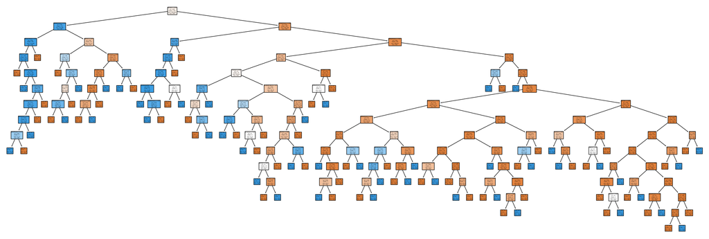

```python
DTClassifer = DecisionTreeClassifier()
DTClassifer.fit(XTrain, YTrain)
visualizeDT(DTClassifer, trainData)
prediction = DTClassifer.predict(XTest)
```

```python
def visualizeConMat(confusionMat):
    plt.figure(figsize=(10,7))
    labels = ['LOW', 'HIGH']
    sb.heatmap(confusionMat, annot=True, fmt='d', cmap='Blues', xticklabels=labels, yticklabels=labels)
    plt.title('Confusion Matrix')
    plt.ylabel('Actual label')
    plt.xlabel('Predicted label')
    plt.show()
```

```
Accuracy is: 89.06%
```

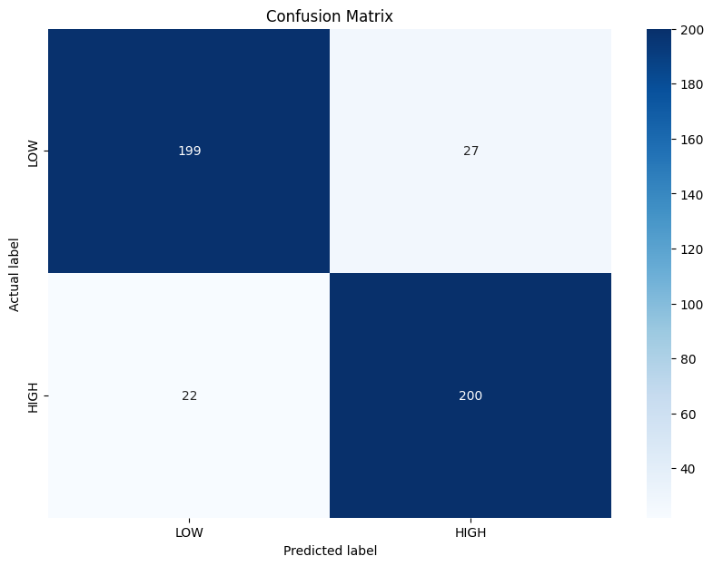

```python
confusionMat = confusion_matrix(YTest, prediction)
accuracy = calculate_accuracy(confusionMat)
print(f"Accuracy is: {accuracy:.2%}")
visualizeConMat(confusionMat)
```

### K Nearest Neighbors

```python
KNNClassifier = KNeighborsClassifier()
KNNClassifier.fit(XTrain, YTrain)
prediction = KNNClassifier.predict(XTest)
```

```
Accuracy is: 85.27%
```

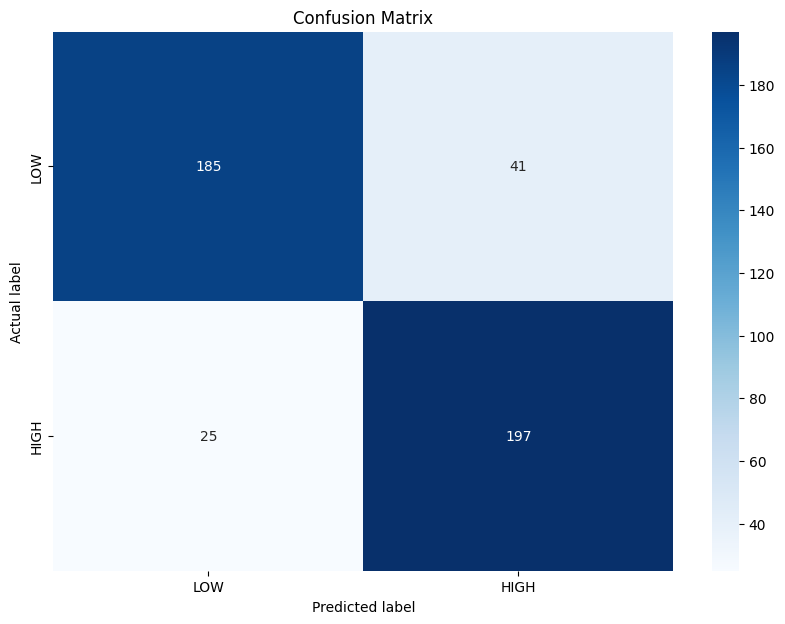

```python
confusionMat = confusion_matrix(YTest, prediction)
accuracy = calculate_accuracy(confusionMat)
print(f"Accuracy is: {accuracy:.2%}")
visualizeConMat(confusionMat)
```

```python
LRClassifier = LogisticRegression()
LRClassifier.fit(XTrain, YTrain)
prediction = LRClassifier.predict(XTest)
```

```
Accuracy is: 88.39%
```

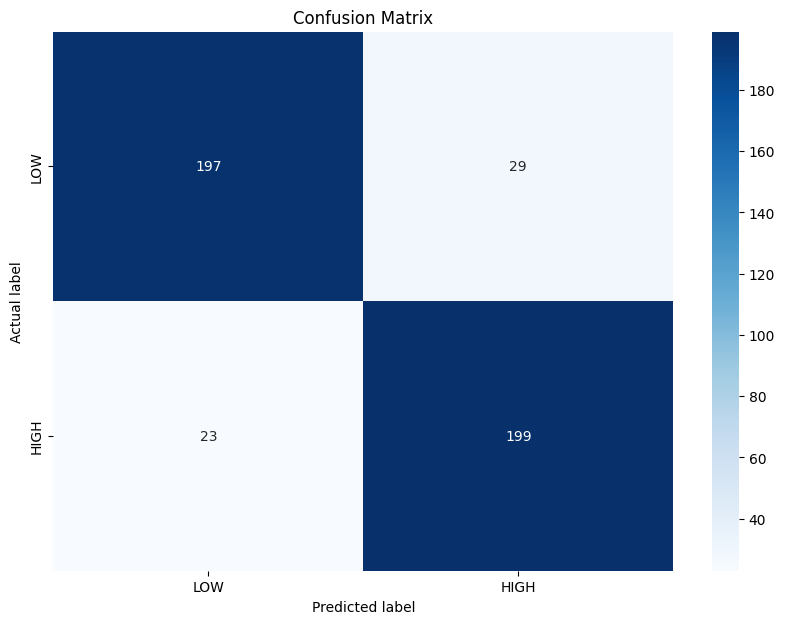

```python
confusionMat = confusion_matrix(YTest, prediction)
accuracy = calculate_accuracy(confusionMat)
print(f"Accuracy is: {accuracy:.2%}")
visualizeConMat(confusionMat)
```

## SearchGridCV:

We'll use a method called GridSearchCV to look for the very best hyperparameters for each model.

```
Best Parameters            : {'criterion': 'gini', 'max_depth': 5, 'min_samples_leaf': 7, 'min_samples_split': 2, 'random_state': 54, 'splitter': 'best'}
Decison Tree Test Accuracy : 92.86%
Decison Tree Train Accuracy: 94.98%
```

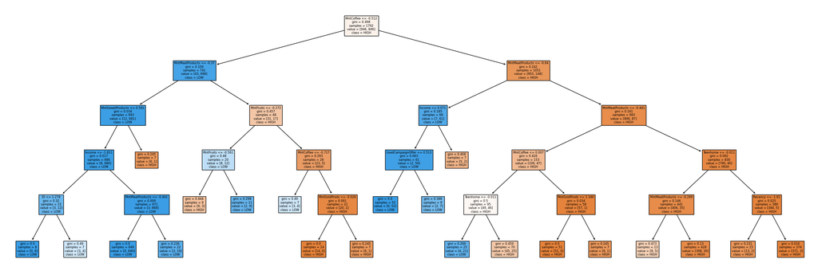

```python
grid = {
    "criterion": ["gini", "entropy"],
    "splitter": ["best", "random"],
    "max_depth": list(range(1, 11)) + [None],
    "min_samples_split": range(2, 11),
    "min_samples_leaf": range(1, 11),
    "random_state": [54],
}

gridSearchDT = GridSearchCV(
    estimator=DecisionTreeClassifier(),
    param_grid=grid,
    scoring="accuracy",
    cv=10,
    n_jobs=-1,
)

gridSearchDT.fit(XTrain, YTrain)
print(f"Best Parameters            : {gridSearchDT.best_params_}")
print(f"Decison Tree Test Accuracy : {gridSearchDT.score(XTest, YTest):.2%}")
print(f"Decison Tree Train Accuracy: {gridSearchDT.score(XTrain, YTrain):.2%}")
visualizeDT(gridSearchDT.best_estimator_, trainData)
```

```python
grid = {
    "n_neighbors": list(range(1, 10)) + list(range(20, 61, 10)),
    "weights": ["uniform", "distance"],
    "metric": ["euclidean", "manhattan", "minkowski"],
    "algorithm": ["auto", "ball_tree", "kd_tree", "brute"],
    "leaf_size": [10, 20],
    "p": [1, 2],
}

gridSearchKNN = GridSearchCV(
    estimator=KNeighborsClassifier(),
    param_grid=grid,
    scoring="accuracy",
    cv=10,
    n_jobs=-1,
)

gridSearchKNN.fit(XTrain, YTrain)
print(f"Best Parameters   : {gridSearchKNN.best_params_}")
print(f"KNN Test Accuracy : {gridSearchKNN.score(XTest, YTest):.2%}")
print(f"KNN Train Accuracy: {gridSearchKNN.score(XTrain, YTrain):.2%}")
```

```
Best Parameters   : {'algorithm': 'auto', 'leaf_size': 10, 'metric': 'manhattan', 'n_neighbors': 20, 'p': 1, 'weights': 'distance'}
KNN Test Accuracy : 87.95%
KNN Train Accuracy: 100.00%
```

```python
grid = {
    "C": [0.001, 0.01, 0.1, 1, 10, 100, 1000],
    "penalty": ["l2"],
    "solver": ["newton-cg", "lbfgs", "liblinear", "sag", "saga"],
}
gridSearchLR = GridSearchCV(
    estimator=LogisticRegression(),
    param_grid=grid,
    scoring="accuracy",
    cv=10,
    n_jobs=-1,
)
gridSearchLR.fit(XTrain, YTrain)
print(f"Best Parameters                   : {gridSearchLR.best_params_}")
print(f"Logistic Regression Test Accuracy : {gridSearchLR.score(XTest, YTest):.2%}")
print(f"Logistic Regression Train Accuracy: {gridSearchLR.score(XTrain, YTrain):.2%}")
```

```
Best Parameters                   : {'C': 1, 'penalty': 'l2', 'solver': 'newton-cg'}
Logistic Regression Test Accuracy : 88.39%
Logistic Regression Train Accuracy: 92.19%
```

### Question 21: Define overfitting and underfitting, and then determine whether they’ve occurred in this scenario.

`Overfitting` happens when a model learns the training data so well that it doesn’t do well with new data. It can occur if the model is too detailed or if there isn’t enough training data.

`Underfitting` occurs when a model is too basic and misses the important trends in the data, making it perform badly on both training and new data. To combat overfitting, you can use more data, simplify your model, or apply techniques that penalize complexity. To fix underfitting, try a more sophisticated model, better data, or add complexity. The aim is to strike a balance where the model is complex enough to learn well but not so much that it doesn’t work with new data.

### Question 24: Study at least two hyperparameters of this model and assess the impact of changing these hyperparameters on your results by drawing diagrams and stating the exact outcomes.

If you adjust the `n_estimators` in a Random Forest, you're basically adding more decision trees. More trees can make the model's predictions more stable, but it will also take longer to train and use more computer memory.

On the other hand, tweaking `max_depth` lets each tree in the Random Forest go deeper, which means it can learn more details. But if you go too deep, your model might get fixated on the training data and not predict as well on data it hasn't seen, which is overfitting.

So, it's like a balancing act. You've got to tune these settings carefully to make sure your model is just right—not too simple, not too complex. Cross-validation can help figure out the sweet spot, keeping your model in check and performing well across the board.

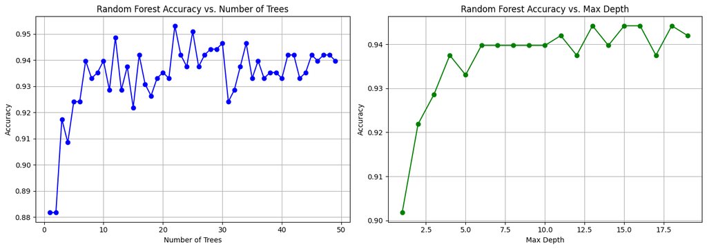

```python
n_estimators_range = range(1, 50)
max_depth_range = range(1, 20)

n_estimator_scores = []
for i in n_estimators_range:
    forest_model = RandomForestClassifier(n_estimators=i)
    forest_model.fit(XTrain, YTrain)
    n_estimator_scores.append(forest_model.score(XTest, YTest))

max_depth_scores = []
for i in max_depth_range:
    forest_model = RandomForestClassifier(max_depth=i)
    forest_model.fit(XTrain, YTrain)
    max_depth_scores.append(forest_model.score(XTest, YTest))

fig, ax = plt.subplots(1, 2, figsize=(14, 5))
ax[0].plot(n_estimators_range, n_estimator_scores, marker='o', linestyle='-', color='b')
ax[0].set_title('Random Forest Accuracy vs. Number of Trees')
ax[0].set_xlabel('Number of Trees')
ax[0].set_ylabel('Accuracy')
ax[0].grid(True)

ax[1].plot(max_depth_range, max_depth_scores, marker='o', linestyle='-', color='g')
ax[1].set_title('Random Forest Accuracy vs. Max Depth')
ax[1].set_xlabel('Max Depth')
ax[1].set_ylabel('Accuracy')
ax[1].grid(True)

plt.tight_layout()
plt.show()
```

## Question 25: Compare the decision tree and random forest results based on bias and variance:

`Bias` is like when your model oversimplifies the problem, missing out on the important patterns. High bias often leads to underfitting, meaning the model doesn’t do well on the training data or any new data it hasn’t seen before.

`Variance` is about how much your model’s predictions change if you use different training data. A model with high variance pays too much attention to the training data, including its noise and details, leading to overfitting. This kind of model does great on the training data but usually fails when it comes to new data.

Random forests try to balance it out. They use a bunch of decision trees to make one strong model that’s less likely to fluctuate with different datasets, cutting down on variance. But if you rely on just one decision tree, you might get stuck on the details – high variance and low bias – and overfit to your training data.

```python
def codeY(Y):
    mapping = {'HIGH': 1, 'LOW': 0}
    return Y.map(mapping)
```

```python
DTClassifer = DecisionTreeClassifier()
DTClassifer.fit(XTrain, YTrain)
forest_model = RandomForestClassifier()
forest_model.fit(XTrain, YTrain)

YTrain_encoded = codeY(YTrain)
YTest_encoded = codeY(YTest)

_, tree_bias, tree_var = bias_variance_decomp(
    DTClassifer, XTrain.values, YTrain_encoded.values, XTest.values,
    YTest_encoded.values, num_rounds=100,random_seed=123)

_, rf_bias, rf_var = bias_variance_decomp(
        forest_model, XTrain.values, YTrain_encoded.values, XTest.values,
        YTest_encoded.values, num_rounds=100,random_seed=123)

print(f"Tree Bias      : {tree_bias:.2f}")
print(f"Tree Variance  : {tree_var:.2f}")
print(f"Forest Bias    : {rf_bias:.2f}")
print(f"Forest Variance: {rf_var:.2f}")
```

```
Tree Bias      : 0.06
Tree Variance  : 0.07
Forest Bias    : 0.06
Forest Variance: 0.02
```

The values are as we predicted

## Question 26: What effect does adding noise to the data in different rows of a dataset have on maintaining the security and privacy of individuals?

Data anonymization is about changing or hiding details in data that can tell us who someone is to keep their privacy safe. One way to do this is by adding ‘noise’, or random information, to the data.

Adding noise makes it hard for someone to pick out and identify a person in that data. It’s like mixing up the pieces of a puzzle so that you can’t easily see the picture anymore. This is good because it protects people from those who might want to figure out who they are by looking for patterns in the data.

But we have to be careful because adding noise can make the data less accurate or useful. If there’s too much noise, we might not be able to understand the data properly anymore.

To handle this, we use something called differential privacy. It’s a set of rules that help us make sure we protect people’s privacy when we’re working with data. It lets us add just enough noise to keep the privacy without ruining the data’s value. It’s like finding just the right volume for music so it’s not too loud to disturb others but still enjoyable for us.

## Question 27: What is the difference between laplace noise and exp noise?

Exponential noise means adding random extra details to a data’s output that are based on how much changing one piece of data can change the output. It uses what’s called the Gaussian mechanism, which follows a bell-shaped curve of probability, typical of the real world. The level of this random extra detail is decided by something we call a privacy budget, with the fancy symbol ε (epsilon). If ε is small, the privacy is stronger, but the data gets more jumbled. If ε is bigger, the privacy is weaker, but the data isn’t as jumbled.

Laplace noise is quite similar to exponential noise since it also adds random details based on how sensitive the computation is. But instead of using a bell-shaped curve, it uses a Laplace distribution, which is a bit spikier and has thicker ends. This means it can mix up the data with bigger random changes than exponential noise, especially when we’re trying to keep data very private with a snug privacy budget ε. People might choose the Laplace way when they need stronger privacy and can handle a bit more jumble in their data.

```python
def add_laplace_noise(data, epsilon):
    sensitivity = 1
    scale = sensitivity / epsilon
    noise = np.random.laplace(loc=0, scale=scale, size=data.shape)
    noisy_data = data + noise
    return noisy_data
```

```python
noisyData = standardizedDF.copy()
features = noisyData.columns.drop(newTarget)
noisyData[features] = add_laplace_noise(noisyData[features], 1)
trainData, testData = train_test_split(noisyData, test_size=0.2)
XTrain, YTrain = divideToXY(trainData)
XTest, YTest = divideToXY(testData)
```

```python
DTClassifer = DecisionTreeClassifier()
DTClassifer.fit(XTrain, YTrain)
prediction = DTClassifer.predict(XTest)
confusionMat = confusion_matrix(YTest, prediction)
accuracy = calculate_accuracy(confusionMat)
print(f"Decision Tree Accuracy after adding noise is: {accuracy:.2%}")
```

```
Decision Tree Accuracy after adding noise is: 65.85%
```

```python
KNNClassifier = KNeighborsClassifier()
KNNClassifier.fit(XTrain, YTrain)
prediction = KNNClassifier.predict(XTest)
confusionMat = confusion_matrix(YTest, prediction)
accuracy = calculate_accuracy(confusionMat)
print(f"KNN Accuracy after adding noise is: {accuracy:.2%}")
```

```
KNN Accuracy after adding noise is: 74.78%
```

```python
LRClassifier = LogisticRegression()
LRClassifier.fit(XTrain, YTrain)
prediction = LRClassifier.predict(XTest)
confusionMat = confusion_matrix(YTest, prediction)
accuracy = calculate_accuracy(confusionMat)
print(f"Logisitic Regression Accuracy after adding noise is: {accuracy:.2%}")
```

```
Logisitic Regression Accuracy after adding noise is: 78.57%
```

## Gradient Boosting Based Methods

### Question 29: difference of bossting tree and decision tree

Boosting Tree and Decision Tree are two different approaches in machine learning for making predictions:

- A **Decision Tree** is like a flowchart that asks a series of yes/no questions about the data. Each question leads you down a path to a decision. It's a standalone model, meaning it makes predictions based on just one tree.
- A **Boosting Tree,** or more accurately, Gradient Boosting, uses lots of decision trees. It's like a team strategy where every new tree tries to fix the errors made by the previous ones. This way, all the trees together make a much stronger model than any single tree could.

### Question 30: How XGBoost works?

**XGBoost in a Nutshell**

XGBoost, or Extreme Gradient Boosting, is a sophisticated machine learning algorithm introduced in 2016. It improves decision tree models by:

- Using multiple weak learner trees in a sequence to correct previous errors.
- Applying regularization techniques to avoid overfitting.
- Enabling fast computations by parallel processing and scalability for big datasets.

Its efficient handling of missing values, advanced tree pruning methods, built-in cross-validation, and a plethora of evaluation metrics make XGBoost a powerful tool for data science tasks, especially in structured data problems.

```python
trainData, testData = train_test_split(standardizedDF, test_size=0.2)
XTrain, YTrain = divideToXY(trainData)
XTest, YTest = divideToXY(testData)

YTrain_encoded = codeY(YTrain)
YTest_encoded = codeY(YTest)

param_grid = {
    'n_estimators': [100, 200, 300],
    'max_depth': [3, 4, 5],
    'learning_rate': [0.01, 0.1, 0.2],
}

grid_search = GridSearchCV(
    estimator=XGBClassifier(random_state=42),
    param_grid=param_grid,
    scoring='accuracy',
    cv=5,
    verbose=1
    )

grid_search.fit(XTrain, YTrain_encoded)
best_model = grid_search.best_estimator_
test_accuracy = best_model.score(XTest, YTest_encoded)
print("Best model parameters   :", grid_search.best_params_)
print(f"Accuracy on the test set: {test_accuracy:.2%}")
```

```
Fitting 5 folds for each of 27 candidates, totalling 135 fits
Best model parameters   : {'learning_rate': 0.2, 'max_depth': 5, 'n_estimators': 100}
Accuracy on the test set: 94.42%
```